# As Gini coefficient increases, what happens to the poor and rich people?

In Economics, the [Gini coefficient](https://en.wikipedia.org/wiki/Gini_coefficient) is designed to measure a "spread" of income. In essence, it can be thought of as the average size of the difference between two randomly chosen people's income, as a fraction of the average income. The higher the Gini coefficient, the more variable should the income distribution be.

Here, we define income as "amounts of money paid to a given person/household". So we are not considering "net" income but rather just the receipts. This is a strictly non-negative number. Either some people paid you something, or you had no receipts at all, but you can't have "negative" receipts . As it's strictly positive, the x=0 boundary may have some interesting properties. In particular, when it comes to explaining violence, we expect that those people at the low end of income distribution have the most motivation to commit violence, for example in order to secure the necessary goods required to sustain life, such as food, or basic shelter. It's well established that violence is much more often committed by people desperate for resources than it is people who are relatively comfortable.

To see what happens as Gini coefficient changes, consider the paper by E.T. Jaynes [Concentration of Distribution at Entropy Maxima](https://bayes.wustl.edu/etj/articles/entropy.concentration.pdf). In this paper, he proves his "Entropy Concentration Theorem" that among all the distributions with a given mean and Gini coefficient (or any other given constraints), they are all in some sense "close to" the maximum entropy distribution. This means that the maximum entropy distribution is a worthwhile distribution to look at because properties of other distributions with similar mean and Gini coefficients are likely to be similar in some sense.

We proceed by directly using NLopt in Julia to maximize the entropy of a distribution subject to constraints of mean = 1 and Gini various given values. Because we are free to rescale the units of measure, this is actually sufficient to handle all distributions with a given Gini and mean any dollar amount.

Using a basis expansion method using Multiquadric Radial Basis functions, we maximize the entropy subject to the constraint, with Gini values from 0.25 to 0.45 spanning the range of Ginis seen in peaceful Western European nations like Czech Republic, Netherlands, France, and Germany, all the way up to countries like the US with a Gini coefficient near 0.40 - 0.45 depending on particular estimation methods.

```
ret = :FTOL_REACHED
ret = :XTOL_REACHED
ret = :XTOL_REACHED
ret = :FTOL_REACHED
ret = :XTOL_REACHED
```

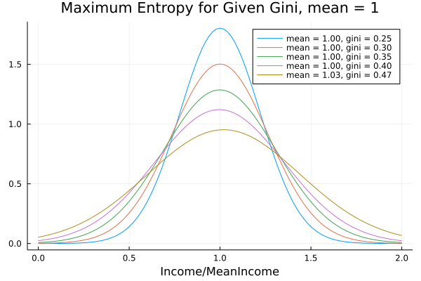

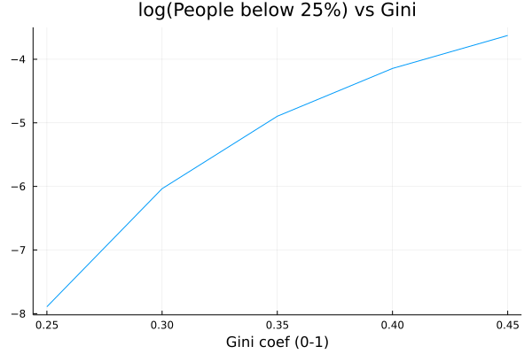

```julia
using Pkg
Pkg.activate(".")
using StaticArrays, StatsPlots, Cubature, NLopt,Printf

mutable struct PdfRbf{T}
    c::SVector{13,T}
    a::SVector{13,T}
    scale::T
    z::T
end

const centers = collect(-1.0:(7/12.0):6.0)
const endpt = 5.0


PdfRbf(c::Vector{T},a::Vector{T},sc,z) where T = PdfRbf(SVector{13,T}(c),SVector{13,T}(a),sc,z)


function thepdf(x,expn)
    return exp(sum(expn.a[i] * sqrt(1.0+((x-expn.c[i])/expn.scale)^2) for i in 1:13))/expn.z
end

function normalize!(p)
    (z,err) = hquadrature(x -> thepdf(x,p),0.0,endpt)
    p.z = p.z * z;
    p
end


function entropy(p)
    (val,err) = hquadrature(x -> -thepdf(x,p) * log(thepdf(x,p)),0.0,endpt)
    val
end

function mean(p::PdfRbf{T}) where T
    (var,err) = hquadrature(x-> x * thepdf(x,p),0.0,endpt)
    var
end

function gini(p::PdfRbf{T}) where T
    (var,err) = hcubature( x -> abs(x[1]-x[2])*thepdf(x[1],p)*thepdf(x[2],p),[0.0,0.0],[endpt,endpt])
    var
end


bar = PdfRbf(SVector{13,Float64}(collect(-1.0:1.0:11.0)),SVector{13,Float64}(rand(13).-0.5),5.0,1.0)
normalize!(bar)

gini(bar)


function ent(x)
    p = PdfRbf(centers,x,3.0*one(x[1]),one(x[1]))
    normalize!(p)
    entropy(p)
end
function gin(x)
    p = PdfRbf(centers,x,3.0*one(x[1]),one(x[1]))
    normalize!(p)
    gini(p)
end

function muval(x)
    p = PdfRbf(centers,x,3.0*one(x[1]),one(x[1]))
    normalize!(p)
    mean(p)
end


pps = let  startx = [-23.510548850507373, -18.100577175661254, -225.13948275760245, -1.5079838437938589, -107.51622646951546, -13.712660431707706, -0.19214600353407665, -5.26144617375756, 0.12979005796514642, 5.264732623647258, 16.157760729712592, 2.9590437873671163, 20.282057772313905] ./ 8.0,
    pps = []
    for g in collect(0.25:0.05:0.45)
        opt = Opt(:LN_COBYLA,13)
        opt.max_objective = (x,g) -> ent(x)
        equality_constraint!(opt, (x,gg) -> gin(x) - g,0.005)
        equality_constraint!(opt, (x,g) -> muval(x) - 1.0,0.005)


        opt.maxtime=120
        opt.ftol_rel = 3e-3
        opt.xtol_rel = 1e-2
        opt.xtol_abs = 1e-3

        (optf,optx,ret) = optimize(opt,startx)
        startx = optx ./ 2.0
        @show(ret)
        pp = PdfRbf(centers,optx,3.0,1.0)
        normalize!(pp)
        push!(pps,pp)
    end
    pps
end


xvals = collect(0.0:0.02:2.0)
p = plot(;xlab="Income/MeanIncome",title="Maximum Entropy for Given Gini, mean = 1");
for pp in pps
    plot!(xvals,thepdf.(xvals,Ref(pp)),label=@sprintf("mean = %.2f, gini = %.2f",mean(pp),gini(pp)))
end
display(p)


let x = [], y = [], plots = []
    for (g,p) in Iterators.zip([0.25 0.3 0.35 0.4 0.45],pps)
        push!(x,g)
        push!(y,hquadrature(x -> thepdf(x,p),0.0,0.25)[1])
    end
    plots = plot(x,log.(y); title = "log(People below 25%) vs Gini",legend=false,xlab="Gini coef (0-1)")
    display(plots)
end
```

Thus, by decreasing the Gini coefficient using income redistribution, we can move people away from the "desperate" region of the income spectrum, dramatically lowering the motivations for violence, and potentially solving many of the violence problems that the US has.

Published from ginimaxent.jmd using Weave.jl v0.10.10 on 2022-08-06.